# Assemblycomparator2 Report

2021-05-10

## Sample overview

|  | input_file | sample | extension | input_file_fasta |
| --- | --- | --- | --- | --- |
| 1 | E8202.fna | E8202 | fna | output_asscom2/samples/E8202/E8202.fa |
| 2 | EF_VRE.fna | EF_VRE | fna | output_asscom2/samples/EF_VRE/EF_VRE.fa |
| 3 | ISMMS_VRE_1.fna | ISMMS_VRE_1 | fna | output_asscom2/samples/ISMMS_VRE_1/ISMMS_VRE_1.fa |

## Assembly statistics

Assembly statistics is provided by assembly-stats.

|  | sample | total_length | number | mean_length | longest | shortest | N_count | Gaps | N50 | N50n | N70 | N70n | N90 | N90n |
| --- | --- | --- | --- | --- | --- | --- | --- | --- | --- | --- | --- | --- | --- | --- |
| 1 | E8202 | 3276455 | 7 | 468065 | 3014357 | 4203 | 0 | 0 | 3014357 | 1 | 3014357 | 1 | 3014357 | 1 |
| 2 | EF_VRE | 3347130 | 6 | 557855 | 3029645 | 6173 | 0 | 0 | 3029645 | 1 | 3029645 | 1 | 3029645 | 1 |
| 3 | ISMMS_VRE_1 | 3259287 | 6 | 543214.5 | 3130373 | 886 | 0 | 0 | 3130373 | 1 | 3130373 | 1 | 3130373 | 1 |

Lengths of contigs:

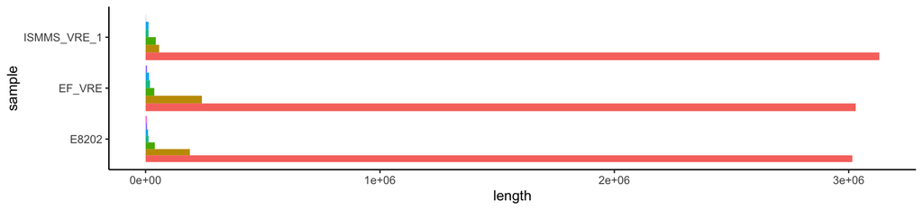

*Fig. 1: Lengths of contigs (fasta records) for each sample. The colors have no intrinsic meaning.*

## Species

Species identification is provided by [Kraken 2](https://github.com/DerrickWood/kraken2/wiki/About-Kraken-2).

|  | sample | percent_hit 1 | clade_hit 1 |
| --- | --- | --- | --- |
| 1 | E8202 | 100 | Enterococcus faecium |
| 2 | EF_VRE | 100 | Enterococcus faecium |
| 3 | ISMMS_VRE_1 | 100 | Enterococcus faecium |

Using the /Users/reasonable/databases/kraken2/k2_standard_8gb_20201202 database.

## MLST

Multi locus sequence typing provided by mlst. The mlst software incorporates components of the [PubMLST](https://pubmlst.org/) database.

|  | sample | scheme | sequence_type | al. 1 | al. 2 | al. 3 | al. 4 | al. 5 | al. 6 | al. 7 |
| --- | --- | --- | --- | --- | --- | --- | --- | --- | --- | --- |
| 1 | E8202 | efaecium | 117 | atpA(9) | ddl(1) | gdh(1) | purK(1) | gyd(1) | pstS(1) | adk(1) |
| 2 | EF_VRE | efaecium | 1478 | atpA(9) | ddl(1) | gdh(1) | purK(1) | gyd(1) | pstS(0) | adk(1) |
| 3 | ISMMS_VRE_1 | efaecium | - | atpA(7) | ddl(1) | gdh(1) | purK(1) | gyd(5) | pstS(1) | adk(~1) |

## NCBI Resistance

Resistance genes provided by [NCBI AMRFinder](https://www.ncbi.nlm.nih.gov/pmc/articles/PMC6811410/) via [Abricate](https://github.com/tseemann/abricate#abricate).

|  | sample | num_found | aacA-ENT1 | ant(6)-Ia | aph(2'')-Ih | aph(3')-IIIa | dfrF | dfrG | eat(A) | erm(B) | erm(T) | msr(C) | sat4 | tet(L) | tet(M) | vanA | vanH-A | vanR-A | vanS-A | vanX-A | vanY-A | vanZ-A |
| --- | --- | --- | --- | --- | --- | --- | --- | --- | --- | --- | --- | --- | --- | --- | --- | --- | --- | --- | --- | --- | --- | --- |
| 1 | E8202 | 11 | 100 | . | . | . | 100.00 | 100 | 100 | 88.89 | . | 100 | . | . | . | 100 | 100 | 100 | 100 | 100 | . | . |
| 2 | EF_VRE | 13 | 100 | . | 89.15 | . | . | 100 | 100 | 100 | . | 100 | . | 100.00 | 100.00 | 100 | 100 | 100 | 100 | 100 | . | . |
| 3 | ISMMS_VRE_1 | 19 | 100 | 100.00 | 89.15;89.15 | 100.00 | . | 100 | 100 | 100 | 100.00 | 100 | 99.82 | 97.53 | 100.00 | 100 | 100 | 100 | 100 | 100 | 100.00 | 100.00 |

## Card Resistance genes

|  | sample | num_found | AAC(6')-Ie-APH(2'')-Ia | AAC(6')-Ii | APH(3')-IIIa | ErmB | ErmT | SAT-4 | aad(6) | dfrF | dfrG | efmA | msrC | tet(L) | tetM | vanA | vanHA | vanRA | vanSA | vanXA | vanYA | vanZA |
| --- | --- | --- | --- | --- | --- | --- | --- | --- | --- | --- | --- | --- | --- | --- | --- | --- | --- | --- | --- | --- | --- | --- |
| 1 | E8202 | 11 | . | 100 | . | 87.82 | . | . | . | 100.00 | 100 | 100 | 100 | . | . | 100 | 100 | 100 | 100 | 100 | . | . |
| 2 | EF_VRE | 13 | 100.00 | 100 | . | 99.87 | . | . | . | . | 100 | 100 | 100 | 100.00 | 100.00 | 100 | 100 | 100 | 100 | 100 | . | . |
| 3 | ISMMS_VRE_1 | 19 | 100.00;100.00 | 100 | 100.00 | 99.87 | 100.00 | 99.82 | 100.00 | . | 100 | 100 | 100 | 97.53 | 100.00 | 100 | 100 | 100 | 100 | 100 | 100.00 | 100.00 |

## Plasmidfinder calls

|  | sample | num_found | rep11a_1_repA(pB82) | rep14a_3_EFAU085p5001(AUS0085p5) | rep17_1_CDS29(pRUM) | rep18a_1_repA(p200B) | rep18b_1_BO23315710(pE1p13) | rep22_1b_repB(pAMalpha1) | rep29_2_EFAU085p4001(Aus0085p4)_Aus0085 | rep2_1_orf1(pRE25) | rep35_2_ORF2(pSMQ172) | repUS15_1_repA(DO3) | repUS15_2_repA(pNB2354p1) | repUS43_1_CDS12738(DOp1) | repUS56_1_EFA0012(pTEF1) |
| --- | --- | --- | --- | --- | --- | --- | --- | --- | --- | --- | --- | --- | --- | --- | --- |
| 1 | E8202 | 5 | . | . | . | . | 100.00 | . | 100.00 | 100.00 | 97.62 | 100.00 | . | . | . |
| 2 | EF_VRE | 4 | 100.00 | . | 100.00 | . | . | . | . | . | . | . | 100.00 | 100.00 | . |
| 3 | ISMMS_VRE_1 | 7 | . | 97.44 | 100.00 | 100.00;100.00 | . | 87.26 | . | . | . | . | 100.00 | 100.00 | 100.00 |

## Pan and Core genome

[Roary](https://sanger-pathogens.github.io/Roary/) the pan genome pipeline computes the number of orthologous genes in a number of core/pan partitions.

The core genome denotes the genes which are conserved between all samples (intersection), whereas the pan genome is the union of all genes across all samples.

[interactive table not shown]

*Table 1: Distribution of genes in different core/pan partitions.*

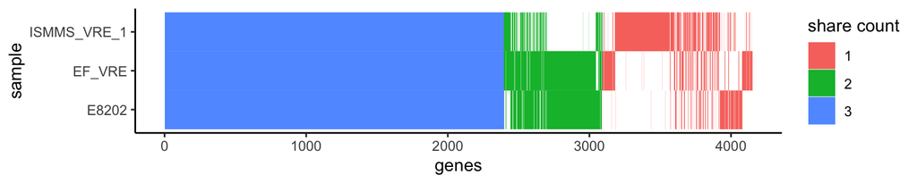

*Fig. 2: Visual distribution of genes in the different samples. The genes are ordered in respect to the number of samples sharing them.*

The assemblycomparator2 pipeline and this report is developed by Oliver Hansen & Carl M. Kobel